# Race_Recognition_en

# 4: Use the Adam optimizer and compare it with SGD.

```python
input = layers.Input(shape = (100, 100, 1))

output = layers.Flatten()(input)
output = layers.Dense(1024, activation="relu")(output)
output = layers.Dense(512, activation="relu")(output)
output = layers.Dense(128, activation="relu")(output)
# output = layers.Dense(1024, activation="relu")(output)
output = layers.Dense(5, activation="softmax")(output)

model2 = models.Model(inputs=input, outputs=output)
model2.compile(optimizer=optimizers.SGD(learning_rate=0.01, momentum=0.50), loss='categorical_crossentropy',metrics=['accuracy', f1_m, precision_m, recall_m])
history2 = model2.fit(TrainData, validation_data=TestData, epochs=10)
```

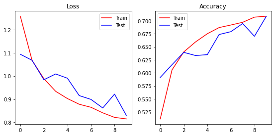

```
Loss :  0.8300195932388306
Accuracy :  70.83392143249512 %
F1 :  69.0703272819519 %
Precision :  78.56248021125793 %
Recall :  61.85137629508972 %
```

```python
fig=plt.figure(figsize=(100, 100))
fig.add_subplot(20,20,1)
plt.plot(history2.history['loss'], color ='r', label = "Train")
plt.plot(history2.history['val_loss'], color ='b', label = "Test")
plt.legend()
plt.title("Loss")
fig.add_subplot(20,20,2)
plt.plot(history2.history['accuracy'], color ='r', label = "Train")
plt.plot(history2.history['val_accuracy'], color ='b', label = "Test")
plt.legend()
plt.title("Accuracy")
plt.show()

metrics = model2.evaluate(TestData, verbose=0)
print("Loss : " , metrics[0])
print("Accuracy : " , metrics[1]*100, "%")
print("F1 : " , metrics[2]*100, "%")
print("Precision : " , metrics[3]*100, "%")
print("Recall : " , metrics[4]*100, "%")
```

```python
input = layers.Input(shape = (100, 100, 1))

output = layers.Flatten()(input)
output = layers.Dense(1024, activation="relu")(output)
output = layers.Dense(512, activation="relu")(output)
output = layers.Dense(128, activation="relu")(output)
# output = layers.Dense(1024, activation="relu")(output)
output = layers.Dense(5, activation="softmax")(output)

model3 = models.Model(inputs=input, outputs=output)
model3.compile(optimizer=optimizers.SGD(learning_rate=0.01, momentum=0.90), loss='categorical_crossentropy',metrics=['accuracy', f1_m, precision_m, recall_m])
history3 = model3.fit(TrainData, validation_data=TestData, epochs=10)
```

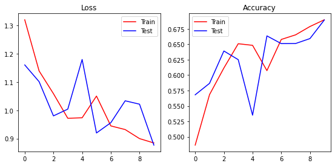

```
Loss :  0.8766830563545227
Accuracy :  68.93545389175415 %
F1 :  66.21564030647278 %
Precision :  78.44489216804504 %
Recall :  57.58328437805176 %
```

```python
fig=plt.figure(figsize=(100, 100))
fig.add_subplot(20,20,1)
plt.plot(history3.history['loss'], color ='r', label = "Train")
plt.plot(history3.history['val_loss'], color ='b', label = "Test")
plt.legend()
plt.title("Loss")
fig.add_subplot(20,20,2)
plt.plot(history3.history['accuracy'], color ='r', label = "Train")
plt.plot(history3.history['val_accuracy'], color ='b', label = "Test")
plt.legend()
plt.title("Accuracy")
plt.show()

metrics = model3.evaluate(TestData, verbose=0)
print("Loss : " , metrics[0])
print("Accuracy : " , metrics[1]*100, "%")
print("F1 : " , metrics[2]*100, "%")
print("Precision : " , metrics[3]*100, "%")
print("Recall : " , metrics[4]*100, "%")
```

```python
model4 = models.Model(inputs=input, outputs=output)
model4.compile(optimizer=optimizers.Adam(learning_rate=0.001), loss='categorical_crossentropy', metrics=['accuracy', f1_m, precision_m, recall_m])
history4 = model4.fit(TrainData,validation_data=TestData, epochs=10)
```

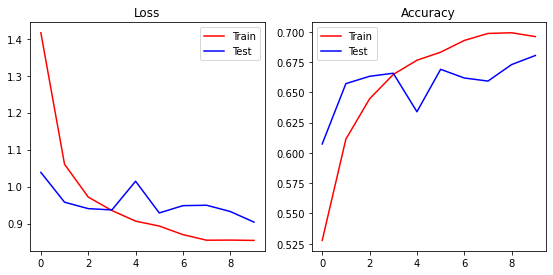

```
Loss :  0.9038649797439575
Accuracy :  68.0354356765747 %
F1 :  67.01640486717224 %
Precision :  74.58193898200989 %
Recall :  61.0265851020813 %
```

```python
fig=plt.figure(figsize=(100, 100))
fig.add_subplot(20,20,1)
plt.plot(history4.history['loss'], color ='r', label = "Train")
plt.plot(history4.history['val_loss'], color ='b', label = "Test")
plt.legend()
plt.title("Loss")
fig.add_subplot(20,20,2)
plt.plot(history4.history['accuracy'], color ='r', label = "Train")
plt.plot(history4.history['val_accuracy'], color ='b', label = "Test")
plt.legend()
plt.title("Accuracy")
plt.show()

metrics = model4.evaluate(TestData, verbose=0)
print("Loss : " , metrics[0])
print("Accuracy : " , metrics[1]*100, "%")
print("F1 : " , metrics[2]*100, "%")
print("Precision : " , metrics[3]*100, "%")
print("Recall : " , metrics[4]*100, "%")
```

# EPOCH:

### 1: Why are Neural Networks trained in several epochs?

Because we use limited data, in order for our network to be trained well and the weights to be updated several times, we need to give the data we have to the network several times so as not to suffer from data shortages. Now, if our data were large enough, we don't need to send them to the network several times.

### 2: Does using more epochs achieve better results?

No - increasing the number of epochs too much will lead to overfitting. That is, the network over-adapts itself to the training data and its error value increases for the test data. To defy this, we can use the following methods.

#### the methods are:

**Simplifying model:**

It means to simplify our network so that our model is not too complicated and cannot be exactly like the training data. For example, by reducing the number of layers and neurons.

**Early Stopping :**

It means to continue training until the data error graphs of both training and testing have a negative slope, and when the error of testing data starts to increase, then we stop training.

**using L1 or L2 Regularization :**

This is how we add a penalty value to the error function, which is equal to the sum of the absolute value or the square of the weights, so that the weights remain small and their various influences are reduced, so that the model becomes simpler.

**Using Dropouts:**

During training, we remove some neurons. This is because we know that different networks become overfit in different ways, so we don't let the network with the same structure become overfit easily.

```python
input = layers.Input(shape = (100, 100, 1))

output = layers.Flatten()(input)
output = layers.Dense(1024, activation="relu")(output)
output = layers.Dense(512, activation="relu")(output)
output = layers.Dense(128, activation="relu")(output)
# output = layers.Dense(1024, activation="relu")(output)
output = layers.Dense(5, activation="softmax")(output)

model5 = models.Model(inputs=input, outputs=output)
model5.compile(optimizer=optimizers.Adam(learning_rate=0.001), loss='categorical_crossentropy', metrics=['accuracy', f1_m, precision_m, recall_m])
history5 = model5.fit(TrainData,validation_data=TestData, epochs=20)
```

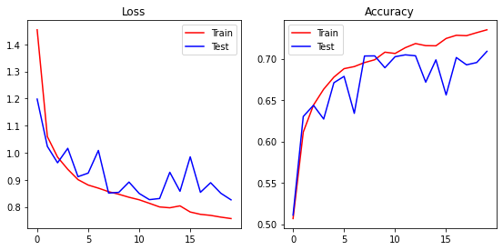

```
Loss :  0.8260605931282043
Accuracy :  70.89017033576965 %
F1 :  69.6261465549469 %
Precision :  78.53485345840454 %
Recall :  62.73622512817383 %
```

```python
fig=plt.figure(figsize=(100, 100))
fig.add_subplot(20,20,1)
plt.plot(history5.history['loss'], color ='r', label = "Train")
plt.plot(history5.history['val_loss'], color ='b', label = "Test")
plt.legend()
plt.title("Loss")
fig.add_subplot(20,20,2)
plt.plot(history5.history['accuracy'], color ='r', label = "Train")
plt.plot(history5.history['val_accuracy'], color ='b', label = "Test")
plt.legend()
plt.title("Accuracy")
plt.show()

metrics = model5.evaluate(TestData, verbose=0)
print("Loss : " , metrics[0])
print("Accuracy : " , metrics[1]*100, "%")
print("F1 : " , metrics[2]*100, "%")
print("Precision : " , metrics[3]*100, "%")
print("Recall : " , metrics[4]*100, "%")
```

# Loss:

### 1: Train the NN with MSE Loss Function and compare the results with categorical cross entropy.

It is clear that the data is not trained well at all and the network does not work properly

### 2: Why is MSE not appropriate for classification?

Because this function is suitable for data that have a continuous distribution and it does not work for binary values because they do not have a normal distribution, suppose our network considers the probability of class 1 to be 51 and the probability of class 2 to 49 and suppose the original answer of class 1 Yes, in this case, the prediction of our network is 1, and if we want to calculate the error with these functions, because the prediction value is exactly equal to the actual value, we have no error, but this is not the case, and we must check the error based on the probabilities we have, not just the output of the network.

```python
input = layers.Input(shape = (100, 100, 1))

output = layers.Flatten()(input)
output = layers.Dense(1024, activation="relu")(output)
output = layers.Dense(512, activation="relu")(output)
output = layers.Dense(128, activation="relu")(output)
# output = layers.Dense(1024, activation="relu")(output)
output = layers.Dense(5, activation="softmax")(output)

model6 = models.Model(inputs=input, outputs=output)
model6.compile(optimizer=optimizers.Adam(learning_rate=0.001), loss=losses.MeanSquaredError(), metrics=['accuracy', f1_m, precision_m, recall_m])
history6 = model6.fit(TrainData,validation_data=TestData, epochs=20)
```

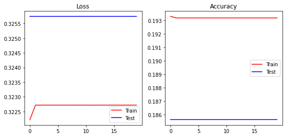

```
Loss :  0.3257487118244171
Accuracy :  18.562790751457214 %
F1 :  18.54780465364456 %
Precision :  18.54780614376068 %
Recall :  18.54780614376068 %
```

```python
fig=plt.figure(figsize=(100, 100))
fig.add_subplot(20,20,1)
plt.plot(history6.history['loss'], color ='r', label = "Train")
plt.plot(history6.history['val_loss'], color ='b', label = "Test")
plt.legend()
plt.title("Loss")
fig.add_subplot(20,20,2)
plt.plot(history6.history['accuracy'], color ='r', label = "Train")
plt.plot(history6.history['val_accuracy'], color ='b', label = "Test")
plt.legend()
plt.title("Accuracy")
plt.show()

metrics = model6.evaluate(TestData, verbose=0)
print("Loss : " , metrics[0])
print("Accuracy : " , metrics[1]*100, "%")
print("F1 : " , metrics[2]*100, "%")
print("Precision : " , metrics[3]*100, "%")
print("Recall : " , metrics[4]*100, "%")
```

# Regularization

### 2: for each layer, use a 0.1 dropout and explain the results.

It is not a good idea to put a dropout for all layers because we remove many parameters. Although this may reduce the complexity of the network, too much of it is not good because it destroys data. In fact, it has reduced the complexity of the network more than needed, and as we can see, the error has increased and the accuracy has decreased, and the noise has also increased.

```python
input = layers.Input(shape = (100, 100, 1))

output = layers.Flatten()(input)
output = layers.Dense(1024, kernel_regularizer= regularizers.L2(l2=0.0001), activation="relu")(output)
output = layers.Dense(512, kernel_regularizer= regularizers.L2(l2=0.0001), activation="relu")(output)
output = layers.Dense(128, kernel_regularizer= regularizers.L2(l2=0.0001), activation="relu")(output)
# output = layers.Dense(1024, activation="relu")(output)
output = layers.Dense(5, kernel_regularizer= regularizers.L2(l2=0.0001), activation="softmax")(output)

model7 = models.Model(inputs=input, outputs=output)
model7.compile(optimizer=optimizers.Adam(learning_rate=0.001), loss='categorical_crossentropy', metrics=['accuracy', f1_m, precision_m, recall_m])
history7 = model7.fit(TrainData,validation_data=TestData, epochs=20)
```

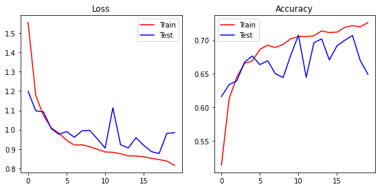

```
Loss :  0.9843602776527405
Accuracy :  64.92757797241211 %
F1 :  61.83609962463379 %
Precision :  72.91176915168762 %
Recall :  53.93577814102173 %
```

```python
fig=plt.figure(figsize=(100, 100))
fig.add_subplot(20,20,1)
plt.plot(history7.history['loss'], color ='r', label = "Train")
plt.plot(history7.history['val_loss'], color ='b', label = "Test")
plt.legend()
plt.title("Loss")
fig.add_subplot(20,20,2)
plt.plot(history7.history['accuracy'], color ='r', label = "Train")
plt.plot(history7.history['val_accuracy'], color ='b', label = "Test")
plt.legend()
plt.title("Accuracy")
plt.show()

metrics = model7.evaluate(TestData, verbose=0)
print("Loss : " , metrics[0])
print("Accuracy : " , metrics[1]*100, "%")
print("F1 : " , metrics[2]*100, "%")
print("Precision : " , metrics[3]*100, "%")
print("Recall : " , metrics[4]*100, "%")
```

```python
input = layers.Input(shape = (100, 100, 1))

output = layers.Flatten()(input)
output = layers.Dense(1024, kernel_regularizer= regularizers.L2(l2=0.0001), activation="relu")(output)
output = layers.Dropout(0.1)(output)
output = layers.Dense(512, kernel_regularizer= regularizers.L2(l2=0.0001), activation="relu")(output)
output = layers.Dropout(0.1)(output)
output = layers.Dense(128, kernel_regularizer= regularizers.L2(l2=0.0001), activation="relu")(output)
output = layers.Dropout(0.1)(output)
# output = layers.Dense(1024, activation="relu")(output)
output = layers.Dense(5, kernel_regularizer= regularizers.L2(l2=0.0001), activation="softmax")(output)

model8 = models.Model(inputs=input, outputs=output)
model8.compile(optimizer=optimizers.Adam(learning_rate=0.001), loss='categorical_crossentropy', metrics=['accuracy', f1_m, precision_m, recall_m])
history8 = model8.fit(TrainData,validation_data=TestData, epochs=20)
```

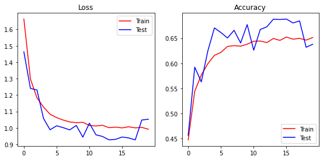

```
Loss :  1.0527288913726807
Accuracy :  63.78849744796753 %
F1 :  55.64962029457092 %
Precision :  77.90766954421997 %
Recall :  43.64790320396423 %
```

```python
fig=plt.figure(figsize=(100, 100))
fig.add_subplot(20,20,1)
plt.plot(history8.history['loss'], color ='r', label = "Train")
plt.plot(history8.history['val_loss'], color ='b', label = "Test")
plt.legend()
plt.title("Loss")
fig.add_subplot(20,20,2)
plt.plot(history8.history['accuracy'], color ='r', label = "Train")
plt.plot(history8.history['val_accuracy'], color ='b', label = "Test")
plt.legend()
plt.title("Accuracy")
plt.show()

metrics = model8.evaluate(TestData, verbose=0)
print("Loss : " , metrics[0])
print("Accuracy : " , metrics[1]*100, "%")
print("F1 : " , metrics[2]*100, "%")
print("Precision : " , metrics[3]*100, "%")
print("Recall : " , metrics[4]*100, "%")
```

```python
l = TestData.filenames
predict = model.predict_generator(TestData)
```

```
WRONG
```

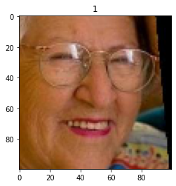

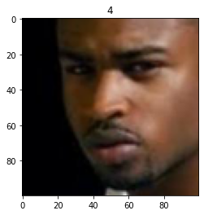

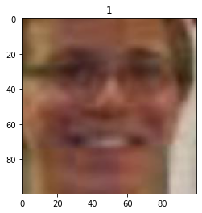

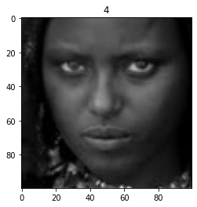

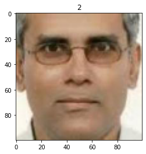

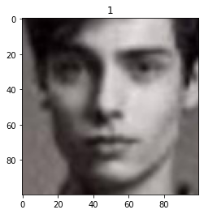

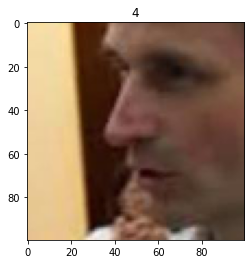

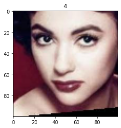

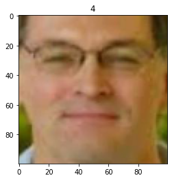

[figure not shown]

```
CORRECT
```

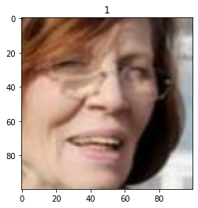

[output not shown]

```python
count_correct = 10
count_wrong = 10
correct_img = []
pred_correct = []
wrong_img = []
pred_wrong = []
np.argmax(predict[0])
# TestData.class_indices[]
for i in range(len(predict)):
  this_c = 4 -list(df[ df['image'] == TestData.filenames[i]].to_dict()['Race'].keys())[0]
  predicted = np.argmax(predict[i])
  if predicted == this_c and count_correct > 0:
    count_correct -= 1
    correct_img.append(TestData.filenames[i])
    pred_correct.append(predicted)
  elif predicted != this_c and count_wrong > 0:
    count_wrong -= 1
    wrong_img.append(TestData.filenames[i])
    pred_wrong.append(predicted)
  elif count_correct+count_wrong == 0:
    break

print('WRONG')
img = []
for adr in wrong_img:
  img.append(preprocessing.image.load_img(adr, target_size=(100, 100)))
for i in range(10):
  plt.imshow(img[i])
  plt.title(pred_wrong[i])
  plt.show()

print('CORRECT')
img = []
for adr in correct_img:
  img.append(preprocessing.image.load_img(adr, target_size=(100, 100)))
for i in range(10):
  plt.imshow(img[i])
  plt.title(pred_correct[i])
  plt.show()
```